# Trình bày và mô tả dữ liệu (buổi 1)

#### 3.1. Biểu đồ cột:

Dùng để đưa ra so sánh giữa các nhóm. Trong Rstudio, để vẽ biểu đồ cột, ta dùng hàm **barplot**:

**barplot(height, names.arg, legend.text, beside, horiz, col, border, main, sub, xlab, ylab, xlim, ylim)**

trong đó:

**height**: véc tơ hoặc ma trận dữ liệu dùng để vẽ biểu đồ.

**names.arg**: tên viết dưới mỗi thanh hoặc nhóm các thanh trong biểu đồ.

**legend.text**: véc tơ gồm các kí tự hoặc dạng logic dùng để ghi chú thích trong biểu đồ.

**beside**: dạng logic, nếu **beside = FALSE** thì các thanh của biểu đồ được vẽ chồng lên nhau, nếu **beside = TRUE** thì các thanh được vẽ cạnh nhau.

**horiz**: dạng logic, nếu **horiz = FALSE** thì các thanh được vẽ vuông góc với trục nằm ngang với thanh đầu tiên nằm ở bên trái, nếu **horiz = TRUE** thì các thanh được vẽ song song với trục nằm ngang với thanh đầu tiên nằm ở dưới cùng.

**col**: màu của các cột.

**border**: màu đường biên của các cột.

**main, sub**: tên của biểu đồ.

**xlab, ylab**: tên trục x; y.

**xlim, ylim**: giới hạn trên các trục.

*Ví dụ:* Ta dùng biểu đồ cột để minh họa dân số của Việt Nam (đơn vị triệu người) và các nước trong khu vực Đông Nam Á trong một số năm với số liệu được cho trong bảng sau:

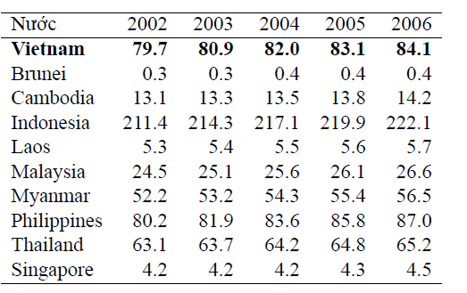

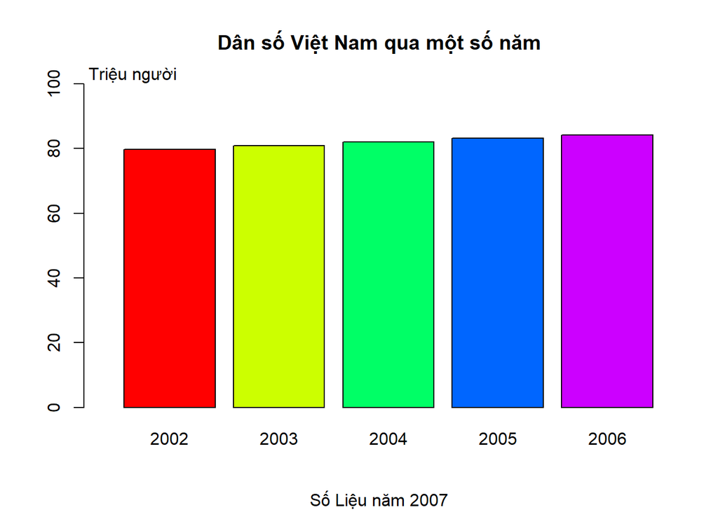

```r
#Nhập tần số từng thanh
SoDan = c(79.7, 80.9, 82.0, 83.1, 84.1)
#Vẽ biểu đồ cột
barplot(SoDan, main = "Dân số Việt Nam qua một số năm",
sub = "Số Liệu năm 2007", names.arg = c(2002,2003,2004,2005,2006), col = rainbow(5), ylim = c(0,100), xlim = c(0,6))
# Chú thích đơn vị trên trục tần số
mtext("Triệu người", at = 0.3)
```